# R Notebook

Exploratory visualizations - What is in the data

Explanatory visualizations - What have we learned from the data

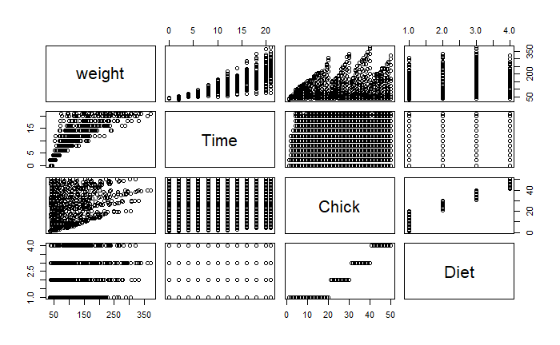

```r
plot(ChickWeight)
```

```r
library(MASS)
whiteside
```

|  | Insul | Temp | Gas |
| --- | --- | --- | --- |
| 1 | Before | -0.8 | 7.2 |
| 2 | Before | -0.7 | 6.9 |
| 3 | Before | 0.4 | 6.4 |
| 4 | Before | 2.5 | 6.0 |
| 5 | Before | 2.9 | 5.8 |
| 6 | Before | 3.2 | 5.8 |
| 7 | Before | 3.6 | 5.6 |
| 8 | Before | 3.9 | 4.7 |
| 9 | Before | 4.2 | 5.8 |
| 10 | Before | 4.3 | 5.2 |

[output cut: 46 more lines]

Checking out the structure of the WhiteSide package

```r
str(whiteside)
```

```
'data.frame':   56 obs. of  3 variables:
 $ Insul: Factor w/ 2 levels "Before","After": 1 1 1 1 1 1 1 1 1 1 ...
 $ Temp : num  -0.8 -0.7 0.4 2.5 2.9 3.2 3.6 3.9 4.2 4.3 ...
 $ Gas  : num  7.2 6.9 6.4 6 5.8 5.8 5.6 4.7 5.8 5.2 ...
```

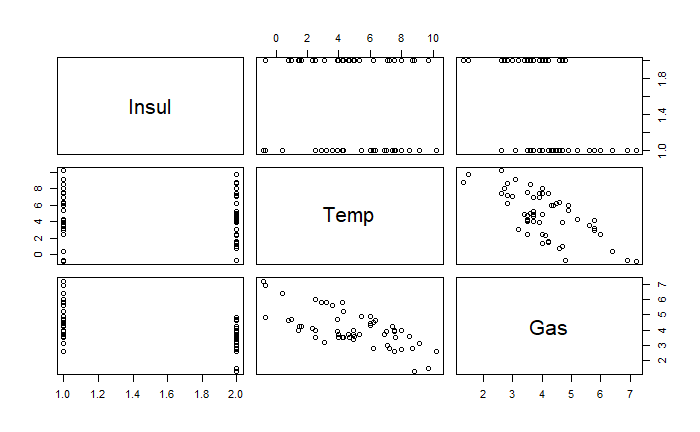

```r
plot(whiteside)
```

Creating an exploratory scatterplot

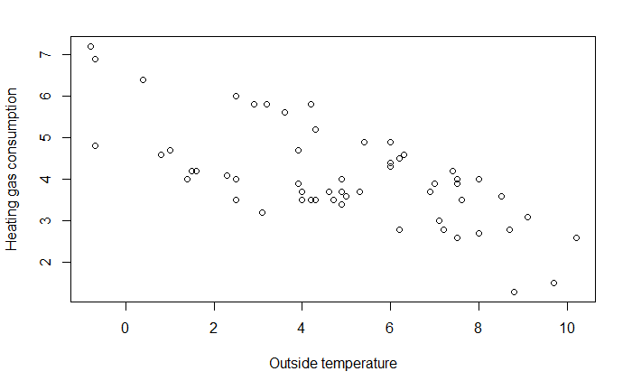

```r
plot(whiteside$Temp, whiteside$Gas, xlab='Outside temperature', ylab='Heating gas consumption')
```

Plot is a generic function, it will present the visualization according to the type of data

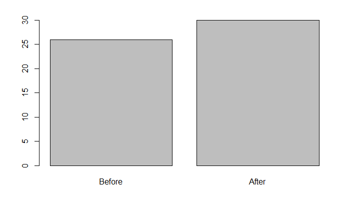

```r
# Apply the plot() function to Insul
plot(whiteside$Insul)
```

Basic visualization of cars 93 dataset

```r
# Cars93 is in your workspace
str(Cars93)
```

```
'data.frame':   93 obs. of  27 variables:
 $ Manufacturer      : Factor w/ 32 levels "Acura","Audi",..: 1 1 2 2 3 4 4 4 4 5 ...
 $ Model             : Factor w/ 93 levels "100","190E","240",..: 49 56 9 1 6 24 54 74 73 35 ...
 $ Type              : Factor w/ 6 levels "Compact","Large",..: 4 3 1 3 3 3 2 2 3 2 ...
 $ Min.Price         : num  12.9 29.2 25.9 30.8 23.7 14.2 19.9 22.6 26.3 33 ...
 $ Price             : num  15.9 33.9 29.1 37.7 30 15.7 20.8 23.7 26.3 34.7 ...
 $ Max.Price         : num  18.8 38.7 32.3 44.6 36.2 17.3 21.7 24.9 26.3 36.3 ...
 $ MPG.city          : int  25 18 20 19 22 22 19 16 19 16 ...
 $ MPG.highway       : int  31 25 26 26 30 31 28 25 27 25 ...
 $ AirBags           : Factor w/ 3 levels "Driver & Passenger",..: 3 1 2 1 2 2 2 2 2 2 ...
 $ DriveTrain        : Factor w/ 3 levels "4WD","Front",..: 2 2 2 2 3 2 2 3 2 2 ...
 $ Cylinders         : Factor w/ 6 levels "3","4","5","6",..: 2 4 4 4 2 2 4 4 4 5 ...
 $ EngineSize        : num  1.8 3.2 2.8 2.8 3.5 2.2 3.8 5.7 3.8 4.9 ...
 $ Horsepower        : int  140 200 172 172 208 110 170 180 170 200 ...
 $ RPM               : int  6300 5500 5500 5500 5700 5200 4800 4000 4800 4100 ...
 $ Rev.per.mile      : int  2890 2335 2280 2535 2545 2565 1570 1320 1690 1510 ...
 $ Man.trans.avail   : Factor w/ 2 levels "No","Yes": 2 2 2 2 2 1 1 1 1 1 ...
 $ Fuel.tank.capacity: num  13.2 18 16.9 21.1 21.1 16.4 18 23 18.8 18 ...
 $ Passengers        : int  5 5 5 6 4 6 6 6 5 6 ...
 $ Length            : int  177 195 180 193 186 189 200 216 198 206 ...
 $ Wheelbase         : int  102 115 102 106 109 105 111 116 108 114 ...
 $ Width             : int  68 71 67 70 69 69 74 78 73 73 ...
 $ Turn.circle       : int  37 38 37 37 39 41 42 45 41 43 ...
 $ Rear.seat.room    : num  26.5 30 28 31 27 28 30.5 30.5 26.5 35 ...
 $ Luggage.room      : int  11 15 14 17 13 16 17 21 14 18 ...
 $ Weight            : int  2705 3560 3375 3405 3640 2880 3470 4105 3495 3620 ...
 $ Origin            : Factor w/ 2 levels "USA","non-USA": 2 2 2 2 2 1 1 1 1 1 ...
 $ Make              : Factor w/ 93 levels "Acura Integra",..: 1 2 4 3 5 6 7 9 8 10 ...
```

```r
# Plot Max.Price vs. Price as red triangles
plot(Cars93$Price, Cars93$Max.Price, col = 'red', pch=17)
# Add Min.Price vs. Price as blue circles
points(Cars93$Price, Cars93$Min.Price, pch=16, col='blue')
```

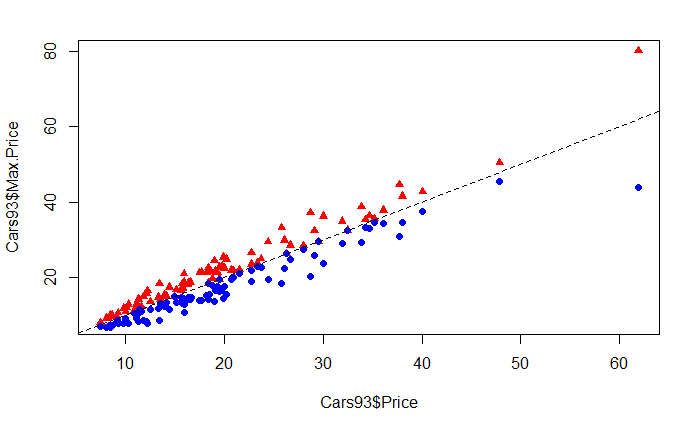

```r
# Add an equality reference line with abline()
abline(a = 0, b = 1, lty = 2)
```

Creating multiple plots in the same plot - Using par function In the below visualization, we have learnt to plot multple graphs in the same image with different titles. Basically everything between each plot statement is attributed to the initial plot.

```r
library(robustbase)
# Animals2 is in your workspace
str(Animals2)
```

```
'data.frame':   65 obs. of  2 variables:
 $ body : num  1.35 465 36.33 27.66 1.04 ...
 $ brain: num  8.1 423 119.5 115 5.5 ...
```

```r
# Set up the side-by-side plot array
par(mfrow = c(1,2))
# First plot: brain vs. body in its original form
plot(Animals2$body, Animals2$brain)
# Add the first title
title('Original representation')
```

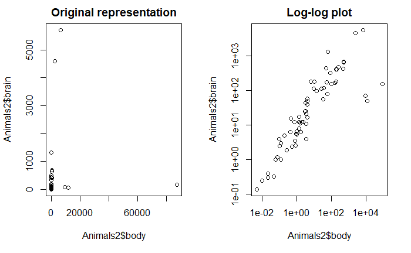

```r
# Second plot: log-log plot of brain vs. body
plot(Animals2$body, Animals2$brain, log = 'xy')
# Add the second title
title('Log-log plot')
```

Pie charts - Avoid as much as possible. Can be used for explanatory(to be used judiciously)

```r
library(insuranceData)
# dataCar is in your workspace
data("dataCar")
str(dataCar)
```

```
'data.frame':   67856 obs. of  11 variables:
 $ veh_value: num  1.06 1.03 3.26 4.14 0.72 2.01 1.6 1.47 0.52 0.38 ...
 $ exposure : num  0.304 0.649 0.569 0.318 0.649 ...
 $ clm      : int  0 0 0 0 0 0 0 0 0 0 ...
 $ numclaims: int  0 0 0 0 0 0 0 0 0 0 ...
 $ claimcst0: num  0 0 0 0 0 0 0 0 0 0 ...
 $ veh_body : Factor w/ 13 levels "BUS","CONVT",..: 4 4 13 11 4 5 8 4 4 4 ...
 $ veh_age  : int  3 2 2 2 4 3 3 2 4 4 ...
 $ gender   : Factor w/ 2 levels "F","M": 1 1 1 1 1 2 2 2 1 1 ...
 $ area     : Factor w/ 6 levels "A","B","C","D",..: 3 1 5 4 3 3 1 2 1 2 ...
 $ agecat   : int  2 4 2 2 2 4 4 6 3 4 ...
 $ X_OBSTAT_: Factor w/ 1 level "01101    0    0    0": 1 1 1 1 1 1 1 1 1 1 ...
```

```r
# Set up a side-by-side plot array
par(mfrow = c(1, 2))
# Create a table of veh_body record counts and sort
tbl <- sort(table(dataCar$veh_body),
            decreasing = TRUE)
# Create the pie chart
pie(tbl)
# Give it a title
title("Pie chart")
```

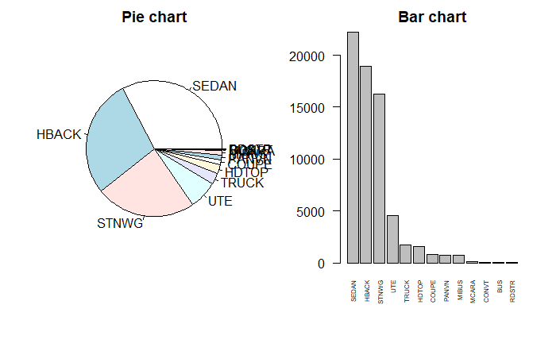

```r
# Create the barplot with perpendicular, half-sized labels
barplot(tbl, las = 2, cex.names = 0.5)
# Add a title
title("Bar chart")
```

Characterising a single variable Most popular plots: Histogram Scatter Density QQ - Heteroskedasticity/Homo - Data points should lie within the 95% confidence interval line

Assumption : All values of numeric should follow gaussian normal distribution. If not, they should be converted to achieve the same. This would be best for our models

hist(uses traditional frequency) vs truehist(uses probability density)

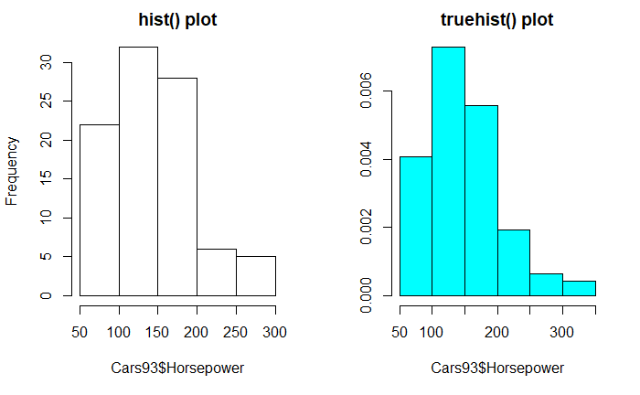

```r
# Set up a side-by-side plot array
par(mfrow=c(1,2))
# Create a histogram of counts with hist()
hist(Cars93$Horsepower, main='hist() plot')
# Create a normalized histogram with truehist()
truehist(Cars93$Horsepower, main='truehist() plot')
```

Density plots as smoothened histograms Adding density curve line Chickwt dataset from datasets package

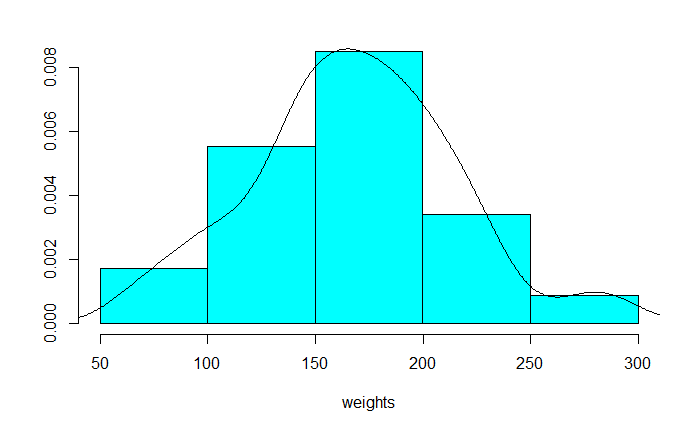

```r
# Create index16, pointing to 16-week chicks
index16 <- which(ChickWeight$Time == 16)
# Get the 16-week chick weights
weights <- ChickWeight$weight[index16]
# Plot the normalized histogram
truehist(weights)
# Add the density curve to the histogram
lines(density(weights))
```

Real data => Difficult to determine probability distribution Enter QQ Plot - Will tell us exactly if the data follows gaussian distribution or not

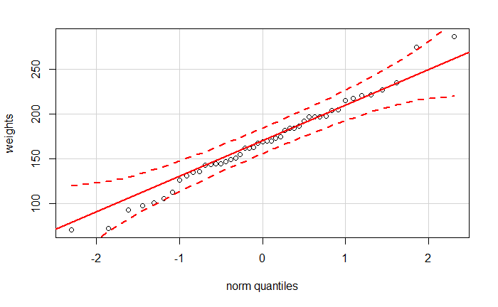

```r
# Load the car package to make qqPlot() available
library(car)
# Create index16, pointing to 16-week chicks
index16 <- which(ChickWeight$Time == 16)
# Get the 16-week chick weights
weights <- ChickWeight$weight[index16]
# Show the normal QQ-plot of the chick weights
qqPlot(weights)
```

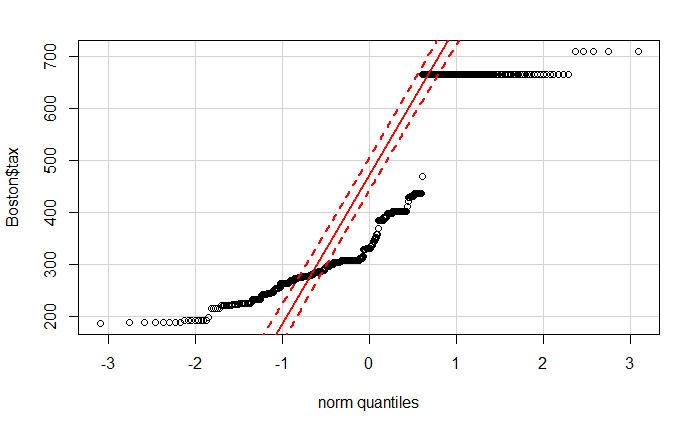

```r
# Show the normal QQ-plot of the Boston$tax data
qqPlot(Boston$tax)
```

Visualizing relations between variables

X and y are numeric

Scatterplots - plot function(x,y) or y~x, data=Datasource

X is numeric , Y is categorical Boxplots

Mosaic plots - X and Y are categorical or X and Y are integer with multiple repeated valeus

`r # Set up a side-by-side plot array par(mfrow=c(1,2)) # Create the standard scatterplot plot(Boston$zn, Boston$rad) # Add the title title('Standard scatterplot')`

`r # Create the sunflowerplot sunflowerplot(Boston$zn, Boston$rad) # Add the title title('Sunflower plot')`

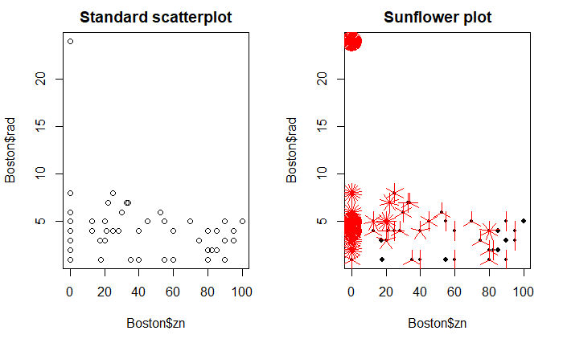

Boxplot - Shows how value of variable differ with respect to unique levels of secondary variable(<10 unique levels ~ good output)

`r # Create a variable-width boxplot with log y-axis & horizontal labels boxplot(crim ~ rad, data = Boston, varwidth=T, log='y', las=1 ) # Add a title title('Crime rate vs. radial highway index')`

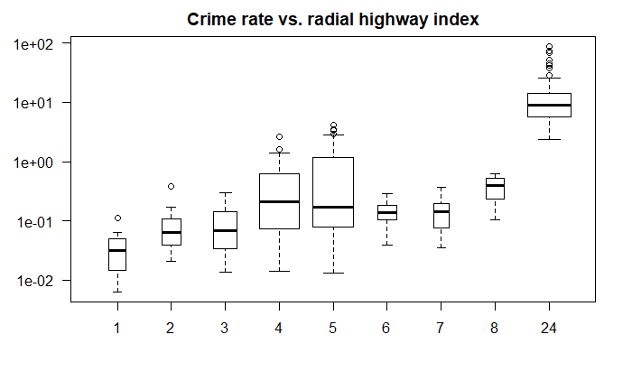

Mosiac plot - Scatter plot between categorical variables

`r # Create a mosaic plot using the formula interface mosaicplot(carb ~ cyl, data = mtcars)`

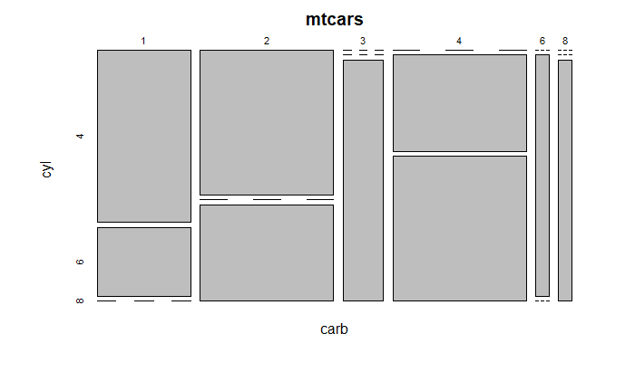

Representing more complex relationships between variables

Bagplot - 2D Boxplot joint distribution of two variables Red star - Median Dark blue - Box - 50% datapoints Light blue - Fence Pts outside are outliers

Correlation coefficient - Useful preliminary view Relationship between two numerical varibales -1 < r < 1 cor - correlation matrix —- Similar to rattle

rpart - Decision tree models rpart - used to fit the tree model text - adds labels to the nodes

`r # Load aplpack to make the bagplot() function available library(aplpack)`

`Loading required package: tcltk`

`r # Create a side-by-side boxplot summary par(mfrow=c(1,2)) boxplot(Cars93$Min.Price, Cars93$Max.Price) # Create a bagplot for the same two variables bagplot(Cars93$Min.Price, Cars93$Max.Price, cex=1.2)`

`r # Add an equality reference line abline(0,1, lty=2)`

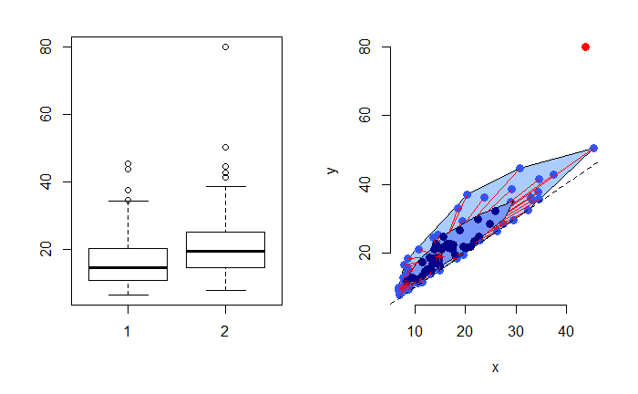

Correlation matrix—————-

`r # Load the corrplot library for the corrplot() function library(corrplot)`

`r # Extract the numerical variables from UScereal numericalVars <- UScereal[,unlist(lapply(UScereal, is.numeric))] # Compute the correlation matrix for these variables corrMat <- cor(numericalVars) # Generate the correlation ellipse plot corrplot(corrMat, method='ellipse')`

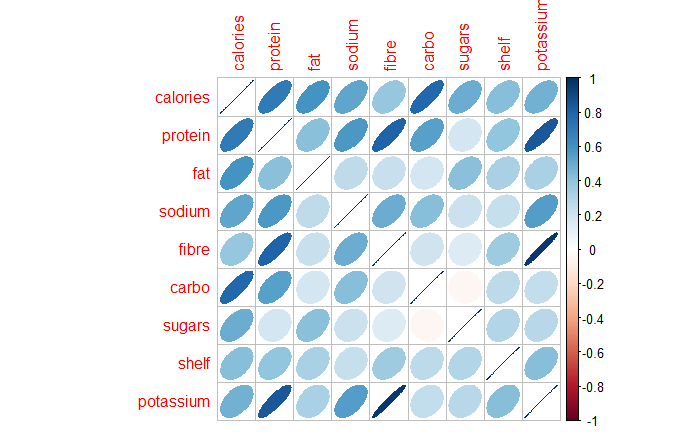

Plotting decision based models

`r # Load the rpart library library(rpart) # Fit an rpart model to predict medv from all other Boston variables tree_model <- rpart(medv ~., data= Boston) # Plot the structure of this decision tree model plot(tree_model) # Add labels to this plot text(tree_model, cex=0.7)`

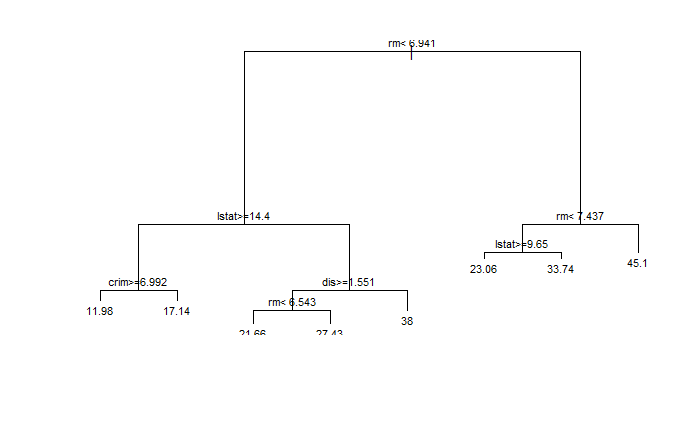

Plot() global function - par - params : mfrow, cex.main (Specifies the size) pch - shape of points

high level - plots(eg. plot()) low level - adding features to plots lines, titles

`r ## Exploring the par function and it's parameters # Assign the return value from the par() function to plot_pars plot_pars <- par() # Display the names of the par() function's list elements names(plot_pars)`

`[1] "xlog" "ylog" "adj" "ann" "ask" "bg" [7] "bty" "cex" "cex.axis" "cex.lab" "cex.main" "cex.sub" [13] "cin" "col" "col.axis" "col.lab" "col.main" "col.sub" [19] "cra" "crt" "csi" "cxy" "din" "err" [25] "family" "fg" "fig" "fin" "font" "font.axis" [31] "font.lab" "font.main" "font.sub" "lab" "las" "lend" [37] "lheight" "ljoin" "lmitre" "lty" "lwd" "mai" [43] "mar" "mex" "mfcol" "mfg" "mfrow" "mgp" [49] "mkh" "new" "oma" "omd" "omi" "page" [55] "pch" "pin" "plt" "ps" "pty" "smo" [61] "srt" "tck" "tcl" "usr" "xaxp" "xaxs" [67] "xaxt" "xpd" "yaxp" "yaxs" "yaxt" "ylbias"`

`r # Display the number of par() function list elements length(plot_pars)`

`[1] 72`

`r # Set up a 2-by-2 plot array par(mfrow=c(2,2)) # Plot the Animals2 brain weight data as points plot(Animals2$brain, type = "p") # Add the title title("points")`

`r # Plot the brain weights with lines plot(Animals2$brain, type = "l") # Add the title title("lines")`

`r # Plot the brain weights as lines overlaid with points plot(Animals2$brain, type = "o") # Add the title title("overlaid")`

`r # Plot the brain weights as steps plot(Animals2$brain, type = "s") # Add the title title("steps")`

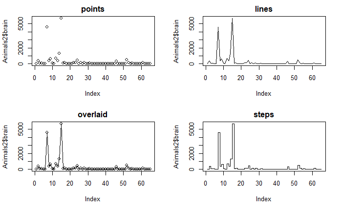

Plotting multiple data frames on the same plot - Exploring the pch types :)

`r # Compute max_hp max_hp <- max(Cars93$Horsepower, mtcars$hp) # Compute max_mpg max_mpg <- max(Cars93$MPG.city, Cars93$MPG.highway, mtcars$mpg) # Create plot with type = "n" plot(max_hp, max_mpg, type = "n", xlim = c(0, max_hp), ylim = c(0, max_mpg), xlab = "Horsepower", ylab = "Miles per gallon") # Add open circles to plot points(mtcars$hp, mtcars$mpg, pch = 1)`

`r # Add solid squares to plot points(Cars93$Horsepower, Cars93$MPG.city, pch = 15) # Add open triangles to plot points(Cars93$Horsepower, Cars93$MPG.highway, pch = 2)`

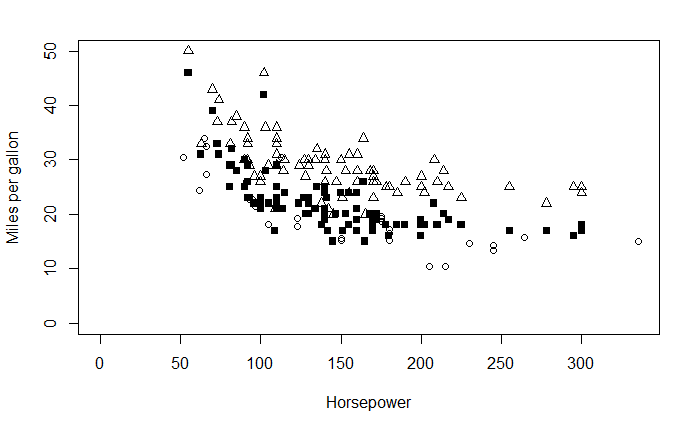

`r ## Exploring the lines function # Create the numerical vector x x <- seq(0, 10, length = 200) # Compute the Gaussian density for x with mean 2 and standard deviation 0.2 gauss1 <- dnorm(x, mean = 2, sd = 0.2) # Compute the Gaussian density with mean 4 and standard deviation 0.5 gauss2 <- dnorm(x, mean = 4, sd = 0.5) # Plot the first Gaussian density plot(x, gauss1, ylab="Gaussian probability density", type="l") # Add lines for the second Gaussian density lines(x, gauss2, lty=2, lwd=3)`

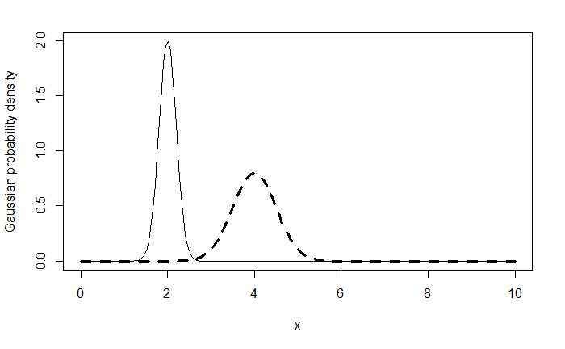

`r ## Exploring point options # Create an empty plot using type = "n" plot(mtcars$hp, mtcars$mpg, type="n", xlab="Horsepower", ylab="Gas mileage") # Add points with shapes determined by cylinder number points(mtcars$hp, mtcars$mpg, pch=mtcars$cyl)`

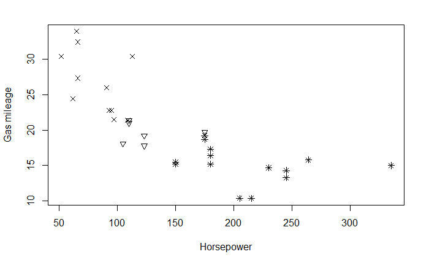

`r # Create a second empty plot plot(mtcars$hp, mtcars$mpg, type="n", xlab="Horsepower", ylab="Gas mileage") # Add points with shapes as cylinder characters points(mtcars$hp, mtcars$mpg, pch = as.character(mtcars$cyl))`

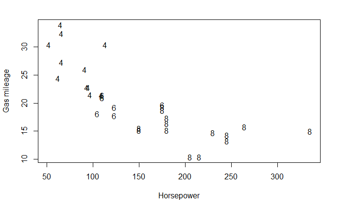

Creating a regression model and adding reference line

`r # Build a linear regression model for the whiteside data linear_model <- lm(Gas ~ Temp, data=whiteside) # Create a Gas vs. Temp scatterplot from the whiteside data plot(whiteside$Temp, whiteside$Gas) # Use abline() to add the linear regression line abline(linear_model, lty=2)`

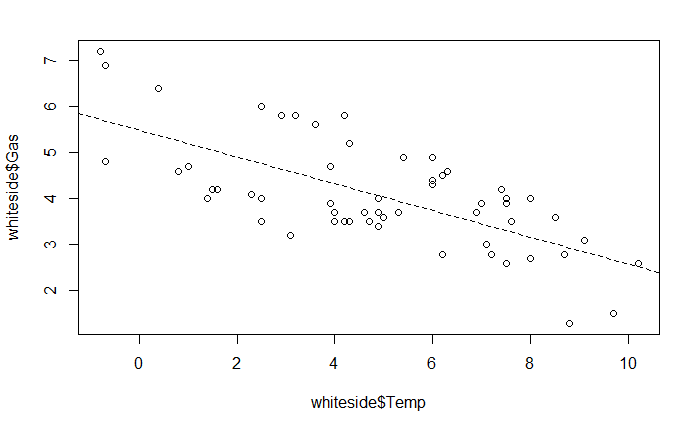

Adding text to plot Plot + Text = Great visualization axis labels titles legends text in plots => new line text(x,y labels, adj - 0.5 0(Left alignment, 1 Right aligned)) srt= angle of text orientation with respect to x axis col - color of the text can be altered using this parameter cex=1.2 - 20% larger font -1 normal 2 bold 3 italics 4 bold and italics

`r ## Exploring text within plots # Create MPG.city vs. Horsepower plot with solid squares plot(Cars93$Horsepower, Cars93$MPG.city, pch=15) # Create index3, pointing to 3-cylinder cars index3<-which(Cars93$Cylinders == 3) # Add text giving names of cars next to data points text(x = Cars93$Horsepower[index3], y = Cars93$MPG.city[index3], labels = Cars93$Make[index3], adj = 0)`

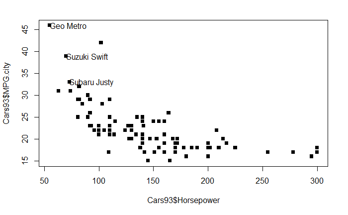

`r ### Some more text properties # Plot MPG.city vs. Horsepower as open circles plot(Cars93$Horsepower, Cars93$MPG.city, pch=1) # Create index3, pointing to 3-cylinder cars index3 <- which(Cars93$Cylinders ==3) # Highlight 3-cylinder cars as solid circles points(Cars93$Horsepower[index3], Cars93$MPG.city[index3], pch=16)`

`r # Add car names, offset from points, with larger bold text text(Cars93$Horsepower[index3], Cars93$MPG.city[index3], labels=Cars93$Make[index3], adj = -0.2, cex=1.2, font=4 )`

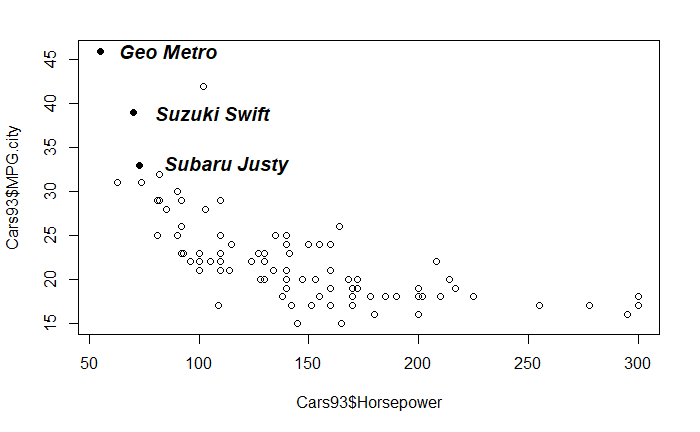

`r ### Playing around with labels god mode # Plot Gas vs. Temp as solid triangles plot(whiteside$Temp, whiteside$Gas, pch=17) # Create indexB, pointing to "Before" data indexB<- which(whiteside$Insul == "Before") # Create indexA, pointing to "After" data indexA<- which(whiteside$Insul == "After") # Add "Before" text in blue, rotated 30 degrees, 80% size text(x = whiteside$Temp[indexB], y =whiteside$Gas[indexB], labels = "Before", col = "blue", srt = 30, cex = 0.8)`

`r # Add "After" text in red, rotated -20 degrees, 80% size text(x = whiteside$Temp[indexA], y =whiteside$Gas[indexA], labels ="After", col = "red", srt = -20, cex = 0.8)`

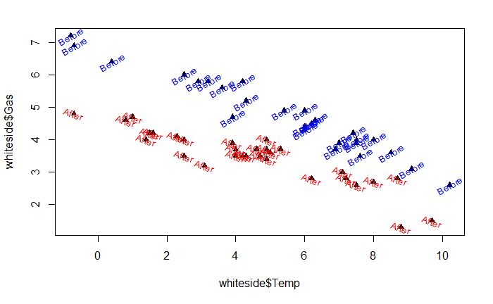

Legends - X legend position, pch and col can be added easily

`r # Set up and label empty plot of Gas vs. Temp plot(whiteside$Temp, whiteside$Gas, type = "n", xlab = "Outside temperature", ylab = "Heating gas consumption") # Create indexB, pointing to "Before" data indexB <- which(whiteside$Insul == "Before") # Create indexA, pointing to "After" data indexA <- which (whiteside$Insul == "After") # Add "Before" data as solid triangles points(whiteside$Temp[indexB], whiteside$Gas[indexB], pch=17)`

[figure not shown]

`r # Create a boxplot of sugars by shelf value, without axes boxplot(sugars ~ shelf, data = UScereal, axes = FALSE) # Add a default y-axis to the left of the boxplot axis(side = 2)`

`r # Add an x-axis below the plot, labelled 1, 2, and 3 axis(side = 1, at = c(1, 2, 3)) # Add a second x-axis above the plot axis(side = 3, at = c(1, 2, 3), labels = c("floor", "middle", "top"))`

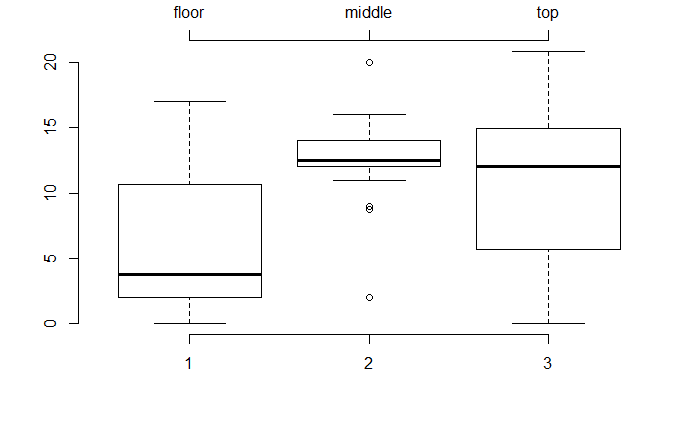